# Netflix Engagement Report Project by Ninh Nguyen

## Source: https://about.netflix.com/en/news/what-we-watched-a-netflix-engagement-report

According to Netlfix:

Since launching our weekly Top 10 and Most Popular lists in 2021, Netflix has provided more information about what people are watching than any other streamer except YouTube. And now we believe it’s time to go further.

Starting today we will publish What We Watched: A Netflix Engagement Report twice a year. This is a comprehensive report of what people watched on Netflix over a six month period1, including:

```
Hours viewed for every title — original and licensed — watched for over 50,000 hours;

The premiere date for any Netflix TV series or film; and

Whether a title was available globally.
```

In total, this report covers more than 18,000 titles — representing 99% of all viewing on Netflix — and nearly 100 billion hours viewed.

Over 60% of Netflix titles released between January and June 2023 appeared on our weekly Top 10 lists. So while this report is broader in scope, the trends reflected in it are very similar to those in the Top 10 lists...

```python
# Import package
import pandas as pd
import matplotlib.pyplot as plt
import seaborn as sns
```

```python
# Read the file
filename = 'What_We_Watched_A_Netflix_Engagement_Report_2023Jan-Jun copy.xlsx'
netflix = pd.read_excel(filename)
netflix
```

|  | Title | Available Globally? | Release Date | Hours Viewed |
| --- | --- | --- | --- | --- |
| 0 | The Night Agent: Season 1 | Yes | 2023-03-23 | 812100000 |
| 1 | Ginny & Georgia: Season 2 | Yes | 2023-01-05 | 665100000 |
| 2 | The Glory: Season 1 // 더 글로리: 시즌 1 | Yes | 2022-12-30 | 622800000 |
| 3 | Wednesday: Season 1 | Yes | 2022-11-23 | 507700000 |
| 4 | Queen Charlotte: A Bridgerton Story | Yes | 2023-05-04 | 503000000 |
| ... | ... | ... | ... | ... |
| 18209 | راس السنة | No | NaT | 100000 |
| 18210 | 心が叫びたがってるんだ。 | No | NaT | 100000 |
| 18211 | 두근두근 내 인생 | No | NaT | 100000 |
| 18212 | 라디오 스타 | No | NaT | 100000 |
| 18213 | 선생 김봉두 | No | NaT | 100000 |

18214 rows × 4 columns

```python
# Summarize the data
netflix.info()
```

```
<class 'pandas.core.frame.DataFrame'>
RangeIndex: 18214 entries, 0 to 18213
Data columns (total 4 columns):
 #   Column               Non-Null Count  Dtype
---  ------               --------------  -----
 0   Title                18214 non-null  object
 1   Available Globally?  18214 non-null  object
 2   Release Date         4855 non-null   datetime64[ns]
 3   Hours Viewed         18214 non-null  int64
dtypes: datetime64[ns](1), int64(1), object(2)
memory usage: 569.3+ KB
```

```python
# View columns
print(netflix.columns)
```

```
Index(['Title', 'Available Globally?', 'Release Date', 'Hours Viewed'], dtype='object')
```

```python
# View values from a column
netflix['Available Globally?'].value_counts()
```

```
Available Globally?
No     13700
Yes     4514
Name: count, dtype: int64
```

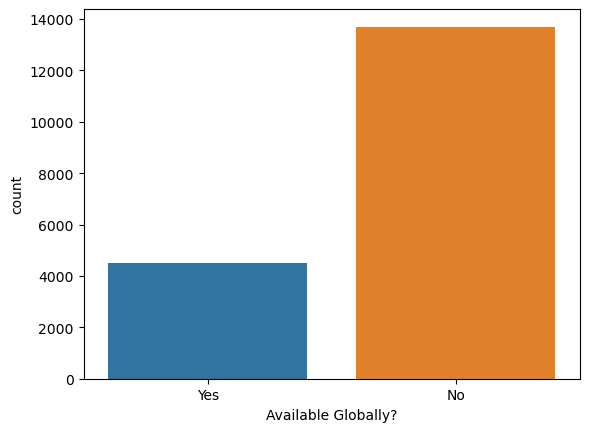

```python
# Count graph
global_viewability = sns.countplot(data=netflix, x='Available Globally?')
```

```python
# View values from a column
netflix['Release Date'].value_counts()
```

```
Release Date
2020-03-20    16
2019-10-18    15
2018-10-19    14
2019-10-25    14
2018-08-31    14
              ..
2019-02-02     1
2021-08-28     1
2021-04-12     1
2020-10-25     1
2020-09-28     1
Name: count, Length: 1665, dtype: int64
```

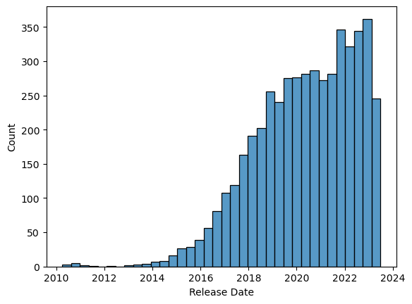

```python
# Histogram graph
release_data = sns.histplot(data=netflix, x='Release Date')
```

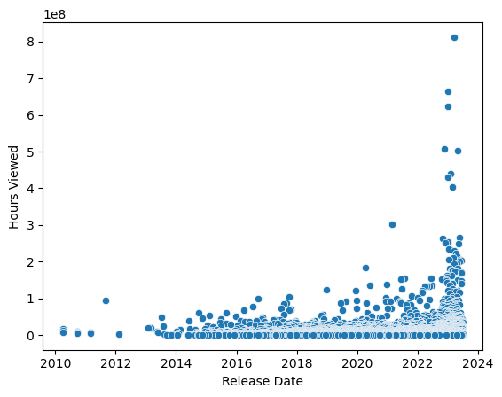

```python
# Display plot
views = sns.scatterplot(data=netflix, x='Release Date', y='Hours Viewed')
```